# CHAID - Resto Provincia Loja Rural

DINEM

# 1 Pobreza por ingresos (1:Pobre, 0: No pobre)

## 1.1 Techo de las viviendas

1: Hormigón (losa, cemento),

2: Fibrocemento,asbesto (eternit, eurolit),

3: Zinc, Aluminio,

4: Teja,

5: Palma, paja u hoja,

6: Otro Material

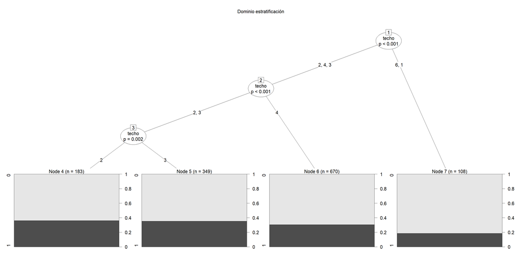

## 1.2 Piso

1: Duela, parquet, tablón tratado o piso flotante,

2: Cerámica, baldosa, vinil o porcelanato,

3: Mármol o marmetón,

4: Ladrillo o cemento,

5: Tabla / tablón no tratado,

6: Caña,

7: Tierra,

8: Otro Material.

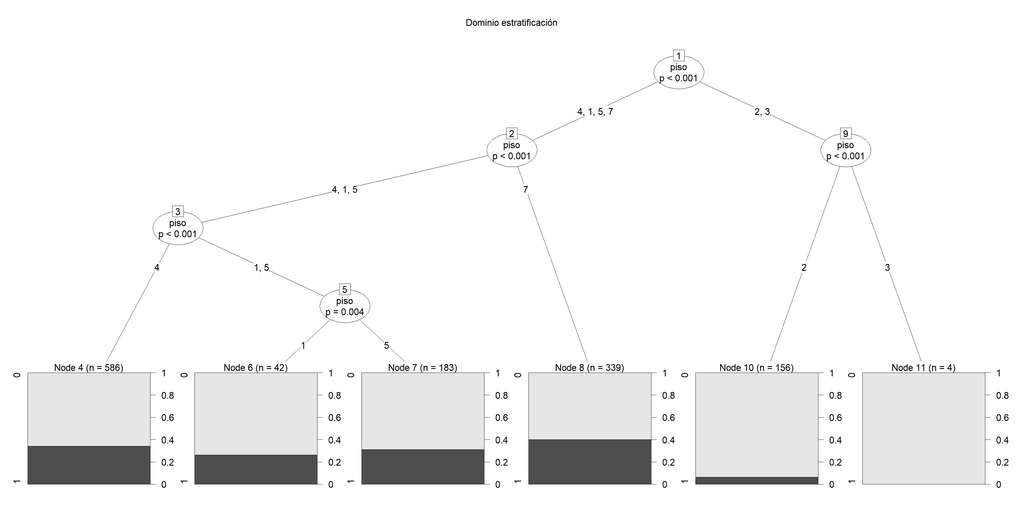

## 1.3 Paredes

1: Hormigón/Ladrillo o Bloque,

2: Asbesto/Cemento (Fibrolit),

3: Adobe o Tapia,

4: Madera,

5: Caña revestida o bahareque,

6: Caña no revestida o estera,

7: Otra Material

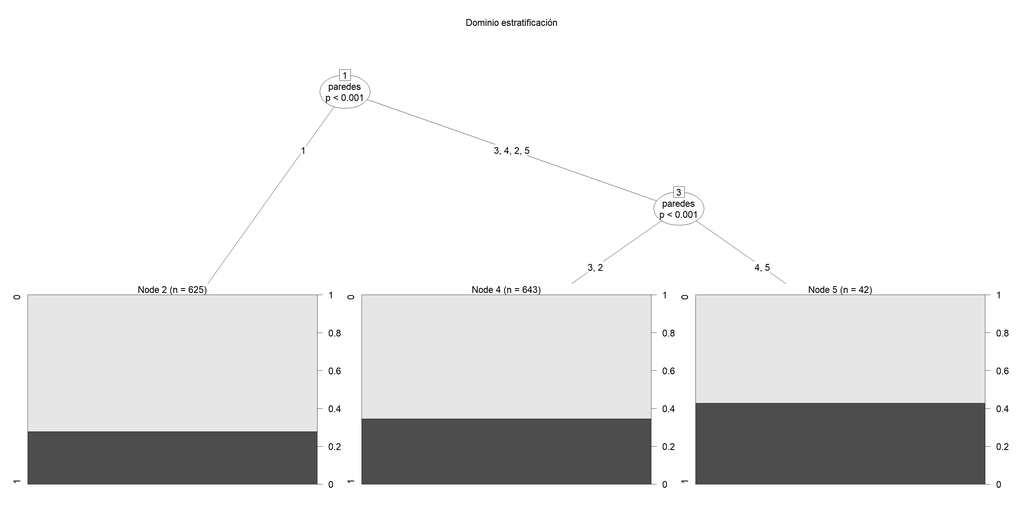

## 1.4 Procedencia del agua

1: Red pública,

2: Pila o llave pública,

3: Otra fuente por tubería,

4: Carro repartidor, triciclo,

5: Pozo,

6: Río, vertiente, acequia,

7: Otro

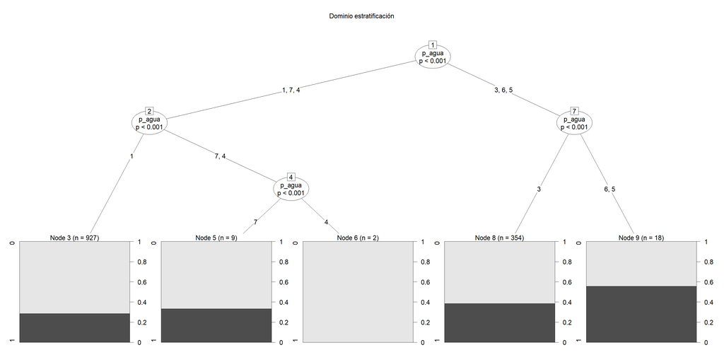

## 1.5 Tubería por dentro del domicilio

1: Por tubería dentro de la vivienda,

2: Por tubería fuera de la vivienda pero en el lote,

3: Por tubería fuera de la vivienda, lote o terreno,

4: No recibe agua por tubería sino por otros medios

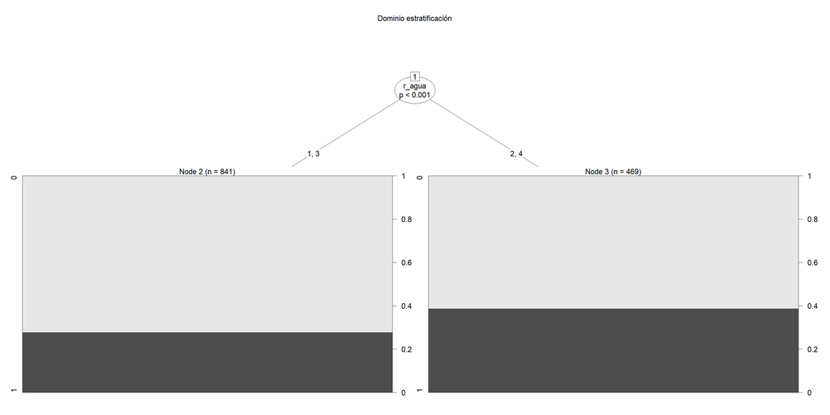

## 1.6 Servicio Higiénico

1: Excusado y alcantarillado,

2: Excusado y pozo séptico,

3: Excusado y pozo ciego,

4: Letrina,

5: No tiene.

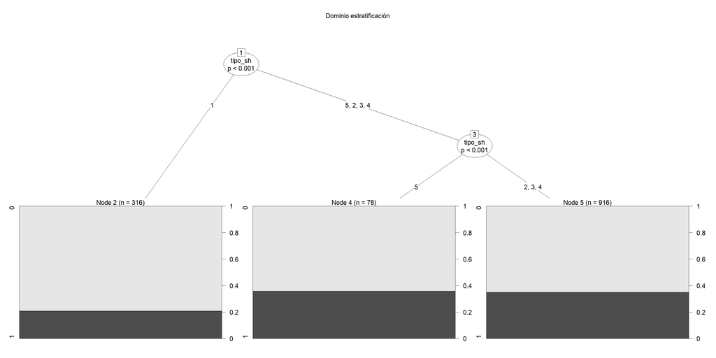

## 1.7 Luz

1: Empresa eléctrica pública,

2: Planta eléctrica privada,

3: Vela, candil, mechero, gas,

4: Ninguno.

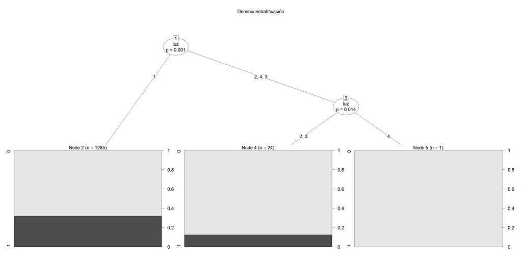

## 1.8 Basura

1: Contratan el servicio,

2: Servicio municipal,

3: Botan a la calle, quebrada, río,

4: La queman, entierran,

5: Otra.

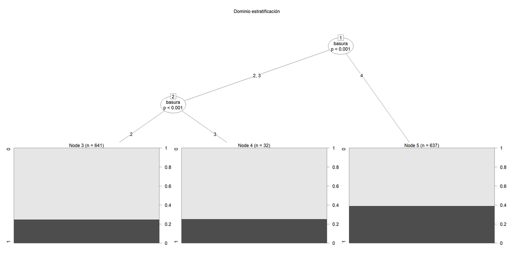

## 1.9 Hacinamiento

0: Hacinado

1: No Hacinado

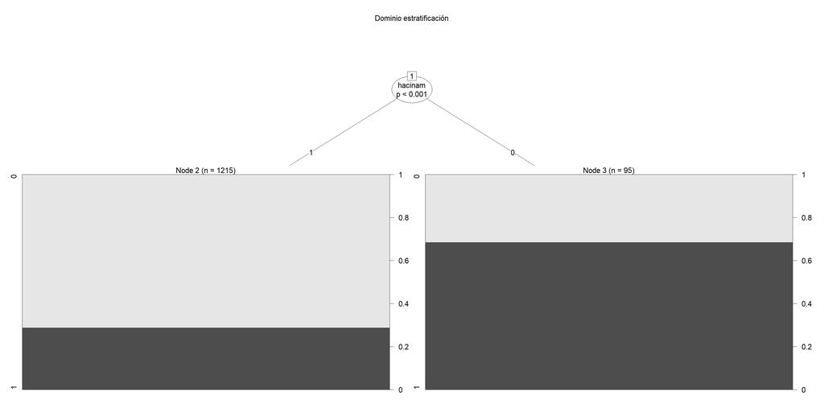

## 1.10 Dependencia

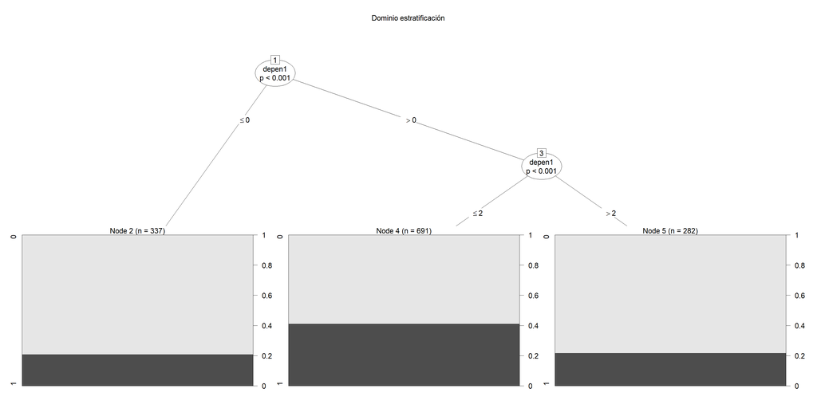

## 1.11 Jefes de hogar Escolaridad

1: >13

0: <=13

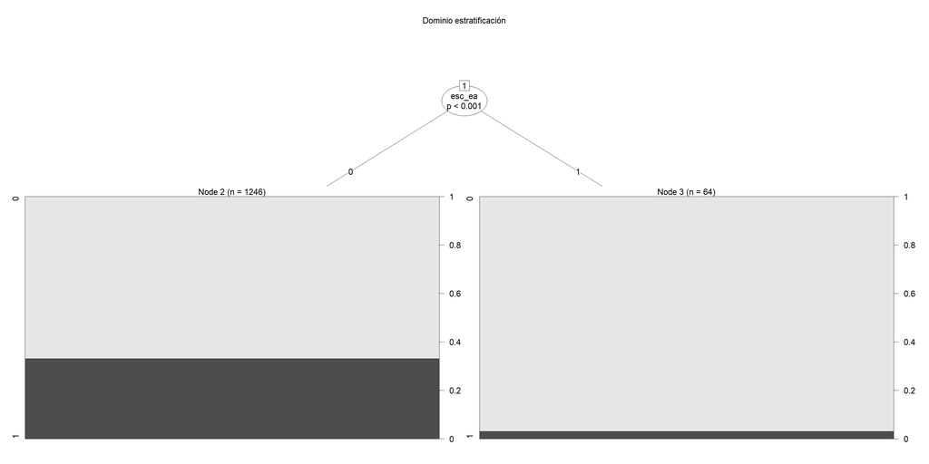

## 1.12 Asistencia de educación general básica (5 a 14 años)

1: Asiste

2: No asiste

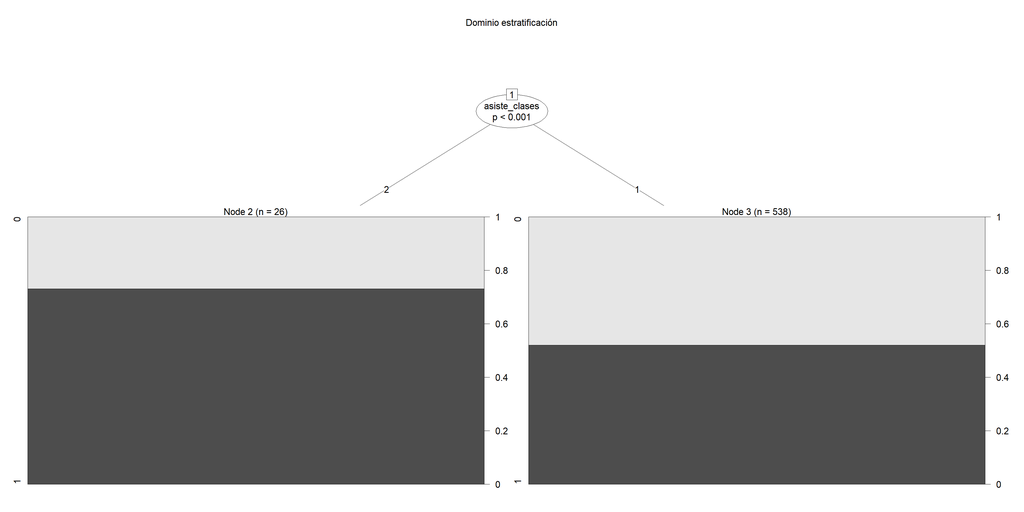

## 1.13 Asistencia ajustada en bachillerato(15 a 17 años))

1: Asiste

2: No asiste

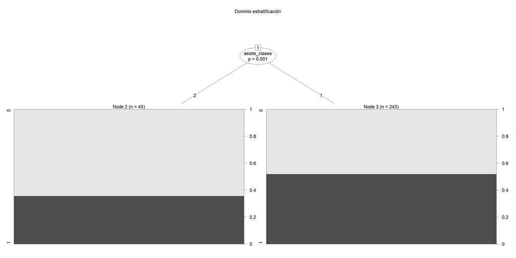

## 1.14 Alfabetismo

1: sabe leer y escribir

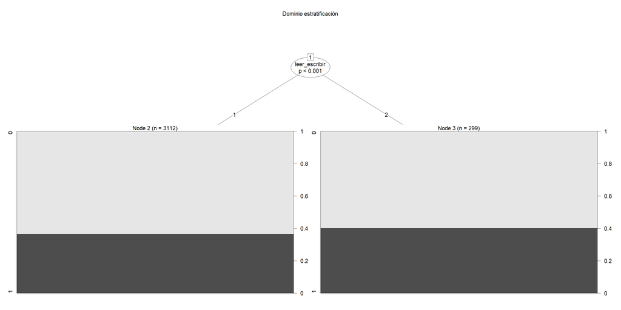

## 1.15 Combustible

1: Gas,

2: Leña/carbón,

3: Electricidad ,

4: Otro

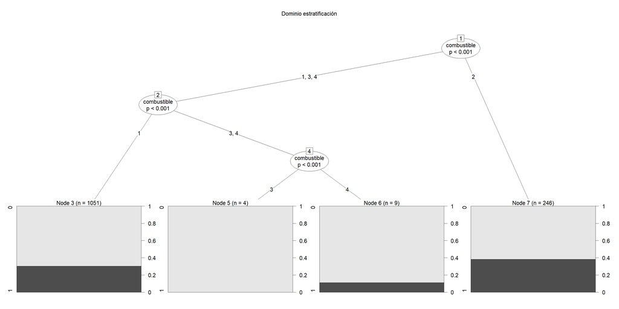

## 1.16 Espacio exclusivo para cocinar

1: Si,

2: No

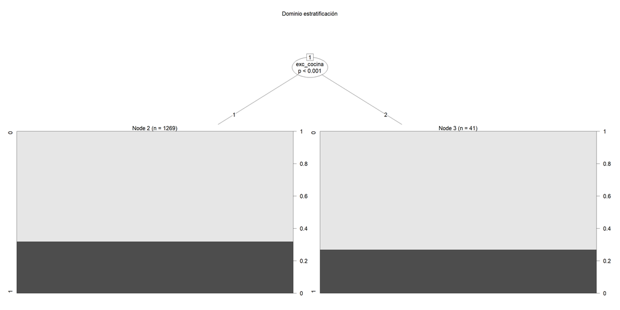

## 1.17 Ducha

1: Exclusivo del hogar,

2: Compartido con otros hogares,

3: No tiene

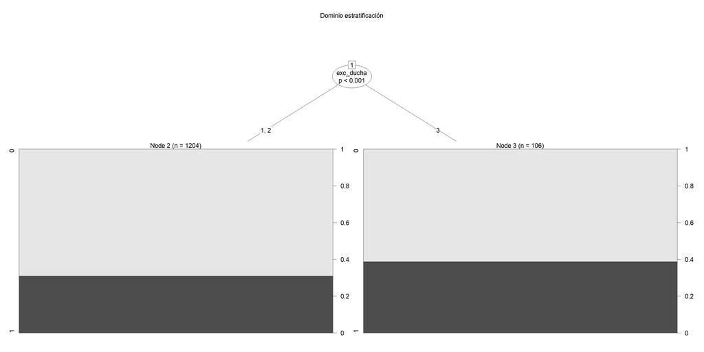

## 1.18 Seguro

[figure not shown]

## 1.19 Autoidentificación

1: Indígena,

2: Afroecuatoriano,

3: Negro,

4: Mulato,

5: Montubio,

6: Mestizo,

7: Blanco,

8: Otro, cual.

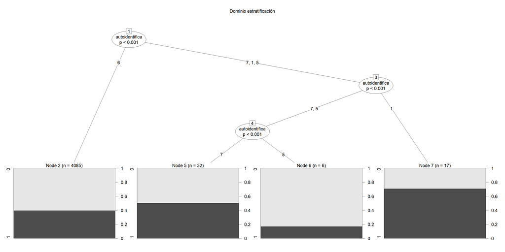

## 1.20 Seguros

1: SG,

2: Voluntario,

3: Campesiono ,

4: ISSFA/ISSPOL,

5: SPhosp,

6: SP_sn_hosp,

7: AUS,

8: Municipales_CP,

9: MSP,

10: Ninguno.

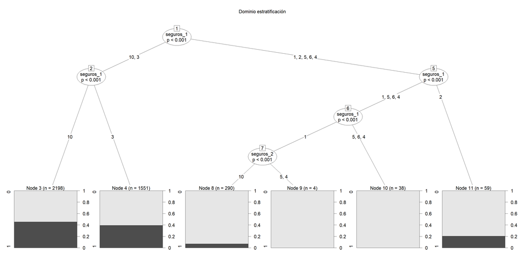

## 1.21 Trabajo infantil

1: Trabajo

2: No Trabajo

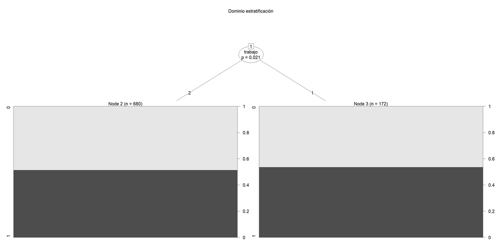

## 1.22 Jóvenes que ni trabajan ni estudian

0: Trabajo o estudia

1: Ni Trabaja ni estudia

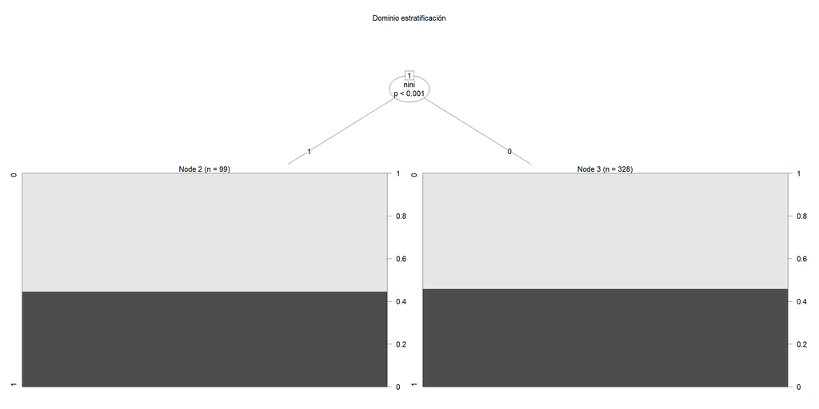

## 1.23 Hogares monoparentales cuyo jefe de hogar es mujer y tiene hijos.

1: Hogar monoparental cuyo jefe de hogar es mujer y tiene hijos

0: Otros

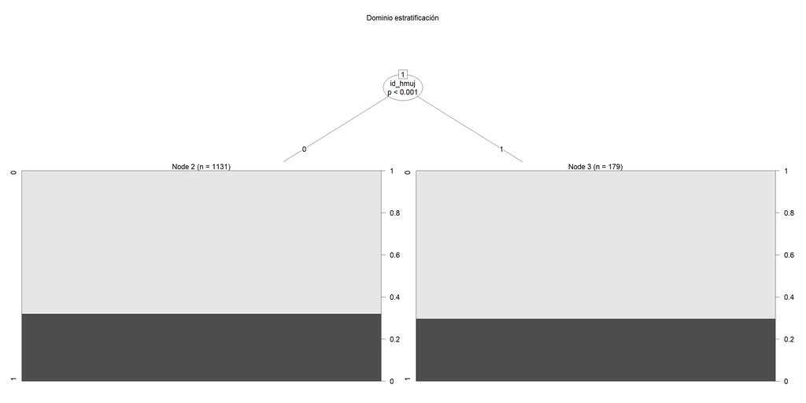

## 1.24 Relación niños mujeres

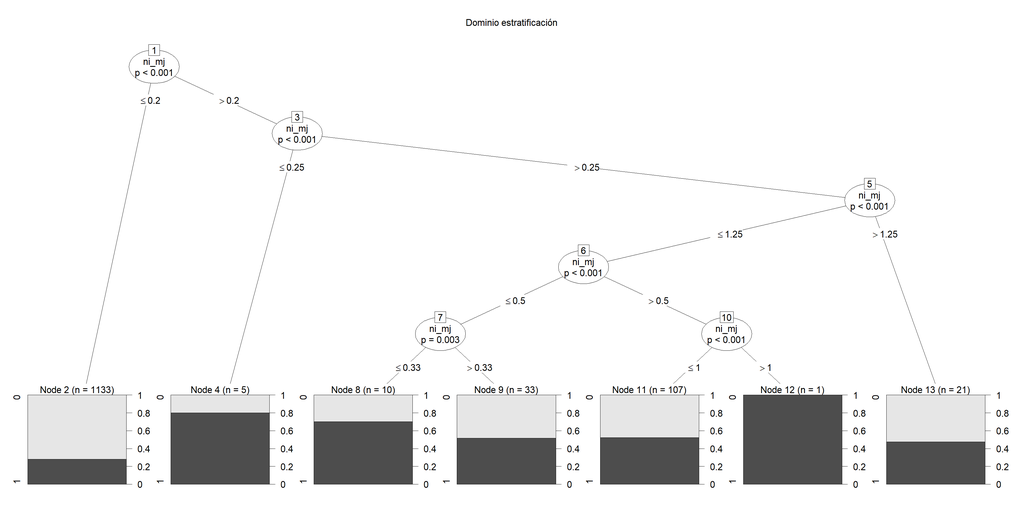

## 1.25 Porcentaje de mujeres y Porcentaje de hombres

1: Hombres

2: Mujeres

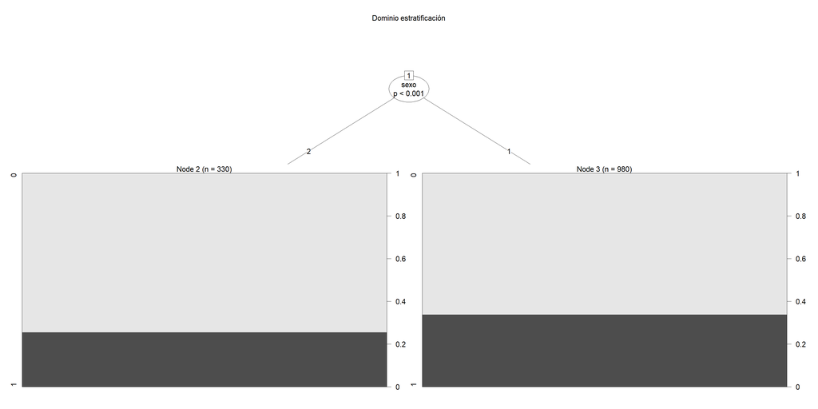

## 1.26 Tasa de juventud

1: Personas entre 15 y 29 años

0: Otros

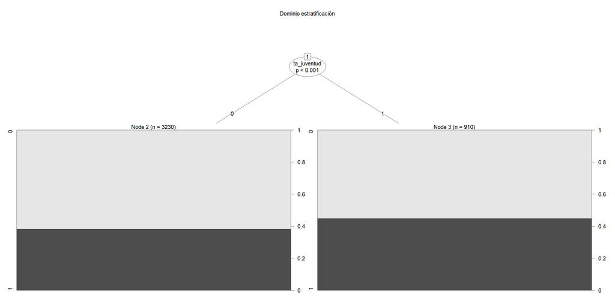

## 1.27 Tasa de Envejecimiento

1: Personas mayores a 65 años

0: Otros

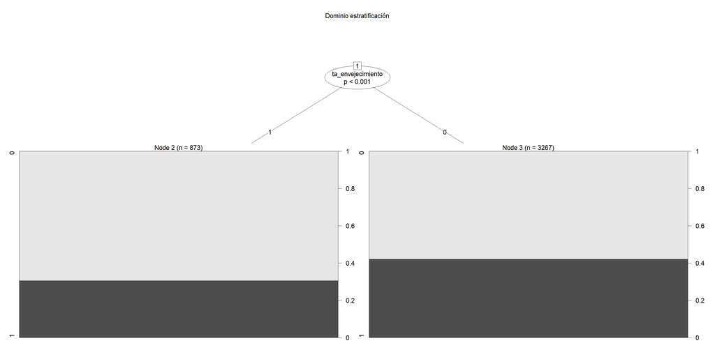